# Coursera Machine Learning Project

Justin L

Saturday, May 23, 2015

## Introduction

This project utilizes weight lifting exercise data from the “Wearable Computing: Accelerometers’ Data Classification of Body Postures and Movements” research (see citation below).

From the research paper: “Six young health participants were asked to perform one set of 10 repetitions of the Unilateral Dumbbell Biceps Curl in five different fashions: exactly according to the specification (Class A), throwing the elbows to the front (Class B), lifting the dumbbell only halfway (Class C), lowering the dumbbell only halfway (Class D) and throwing the hips to the front (Class E).”

The goal of this paper is to use a set of training data in order to develop a machine learning model in order to correctly predict the type of bicep curl (classes A through E) performed on a set of testing data.

## Model Used

For this project, the decision was made due use a Random Forest model due to its robustness and accuracy. Although a 25 sample Bootstrapping resampling is used as a default in the caret implementation of the random forest model in the train function, it was found that extensive memory and time requirements were necessary for the default implementation.

Because my system lacked the necessary RAM, the decision was made to use 3-fold cross validation prior to training the data with the Random Forest Model.

## Data cleaning

It was observed that many of the row data in several columns of the training data was either blank or NA. Due to the lack of useful prediction capability of those columns, these columns were removed from the data set. Also removed were the user name and timestamp data. That resulted in 53 columns of data for a total of 52 predictors (plus the classification).

## Plotting the data

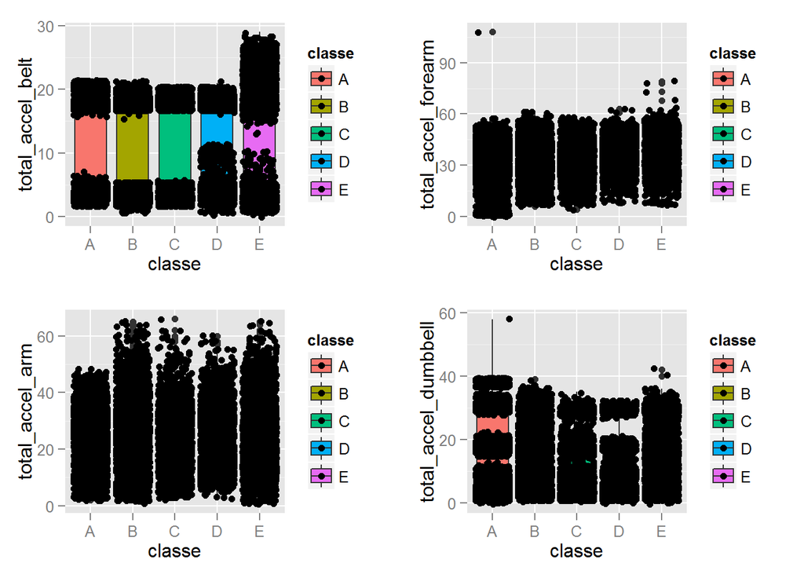

## Training the data

The training set provided was further divided into a sub-training set (75%) and a sub-testing set (25%).

The training set was then run through the Random Forest training model with 3-fold cross validation. The resulting model had an in-sample accuracy of over 99%.

```r
#set up training control function with cross validation
fitControl <- trainControl(method = "cv", number = 3)
modelFit <- train(classe ~., data=training, trControl=fitControl,
                  method="rf", tuneGrid = data.frame(mtry = 6), ntree=100)
modelFit
```

```
## Random Forest
##
## 14718 samples
##    52 predictor
##     5 classes: 'A', 'B', 'C', 'D', 'E'
##
## No pre-processing
## Resampling: Cross-Validated (3 fold)
##
## Summary of sample sizes: 9813, 9812, 9811
##
## Resampling results
##
##   Accuracy   Kappa      Accuracy SD  Kappa SD
##   0.9915747  0.9893406  0.002083781  0.002638361
##
## Tuning parameter 'mtry' was held constant at a value of 6
##
```

```r
test.predict <- predict(modelFit, testing)
confusionMatrix(test.predict, testing$classe)
```

```
## Confusion Matrix and Statistics
##
##           Reference
## Prediction    A    B    C    D    E
##          A 1392    5    0    0    0
##          B    3  943    2    1    0
##          C    0    1  851    9    1
##          D    0    0    2  794    2
##          E    0    0    0    0  898
##
## Overall Statistics
##
##                Accuracy : 0.9947
##                  95% CI : (0.9922, 0.9965)
##     No Information Rate : 0.2845
##     P-Value [Acc > NIR] : < 2.2e-16
##
##                   Kappa : 0.9933
##  Mcnemar's Test P-Value : NA
##
## Statistics by Class:
##
##                      Class: A Class: B Class: C Class: D Class: E
## Sensitivity            0.9978   0.9937   0.9953   0.9876   0.9967
## Specificity            0.9986   0.9985   0.9973   0.9990   1.0000
## Pos Pred Value         0.9964   0.9937   0.9872   0.9950   1.0000
## Neg Pred Value         0.9991   0.9985   0.9990   0.9976   0.9993
## Prevalence             0.2845   0.1935   0.1743   0.1639   0.1837
## Detection Rate         0.2838   0.1923   0.1735   0.1619   0.1831
## Detection Prevalence   0.2849   0.1935   0.1758   0.1627   0.1831
## Balanced Accuracy      0.9982   0.9961   0.9963   0.9933   0.9983
```

The final step was to apply the model to the final test data.

```r
#test on final testing set
final.predict <- predict(modelFit,testing.data)
final.predict
```

```
##  [1] B A B A A E D B A A B C B A E E A B B B
## Levels: A B C D E
```

These final predictions were then assembled into text files and submitted to the Coursera website. All 20 test cases were classified correctly.

### References

Ugulino, W.; Cardador, D.; Vega, K.; Velloso, E.; Milidiu, R.; Fuks, H. Wearable Computing: Accelerometers’ Data Classification of Body Postures and Movements. Proceedings of 21st Brazilian Symposium on Artificial Intelligence. Advances in Artificial Intelligence - SBIA 2012. In: Lecture Notes in Computer Science. , pp. 52-61. Curitiba, PR: Springer Berlin / Heidelberg, 2012. ISBN 978-3-642-34458-9. DOI: 10.1007/978-3-642-34459-6_6.

Read more: http://groupware.les.inf.puc-rio.br/har#sbia_paper_section#ixzz3YRDLWxEV